# Lab3

September 16, 2014

## Announcements

[figure not shown]

## Z scores

[output not shown]

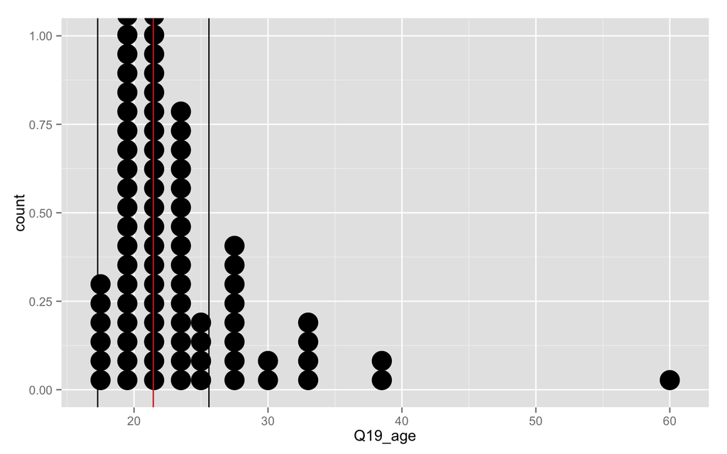

## The distribution of sample means

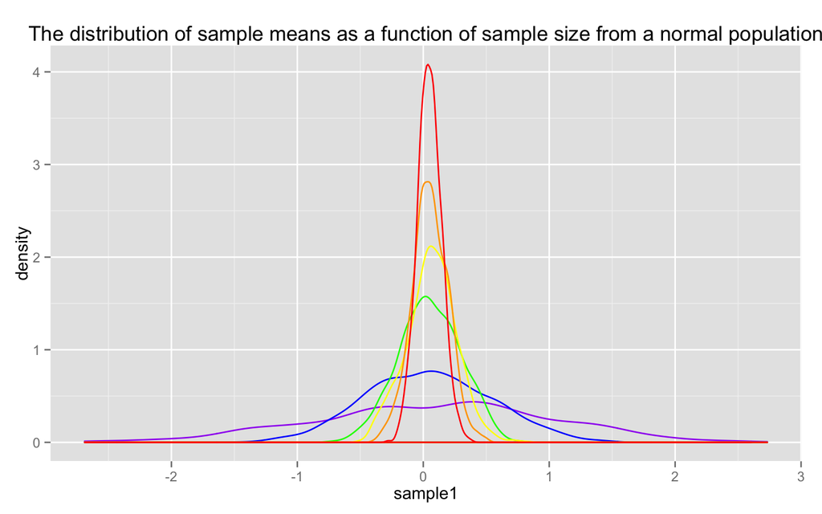

## The distribution of sample sd

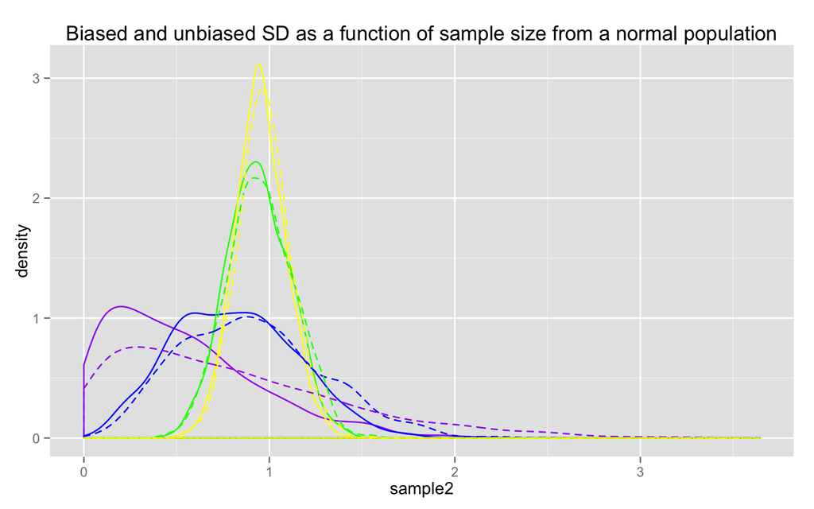

## Getting set up

- Login to your computers with:
- ID: !tmfpsych101
- Password: c@1thinking
- Start Rcommander with `library(Rcmdr)`
- Class survey data is already downloaded for you - check the Class Folder
- You can ignore anything called `NA` - this is how R designates missing things

## Final paper

A research project conducted by you and 2-4 of your closest friends

You must have your group and **three** ideas for a research project by the 18th or 25th

The approved list of ideas is due **IN LECTURE** 30 Sept

For inspiration, try:

- annualreviews.org/journal/psych
- pss.sagepub.com/content/current
- reddit.com/r/psychology
- npr.org/sections/science

## Review time

- 40ish multiple choice questions, 10ish short answer
- Bring a **green** scantron sheet
- Focus on concepts and simple calculations
- Try the practice problems in the text book!

## Things you should know

- What is a variable? What kinds of variables can you have? What is a level?
- What is reliability? What is validity? Can a measure be reliable but not valid?
- What is a population? What is a sample? What is a score?
- What is central tendency? How do we measure it? Which way is best?
- What is variability? How do we measure it? Which way is best?